# Practical Machine Learning

Priya Sebastian

July 19, 2020

# Project Overview

In this project, I’m using a personal activity dataset to build a model that will predict the manner in which a person did the exercise. The steps in the project include - obtaining, analyzing, cleaning and splitting the dataset, using multiple machine learning methods to train the model and test these models on a sample test set. Then confusion matrices are produced to gauge the accuracy of predictions.

# Background

Using devices such as Jawbone Up, Nike FuelBand, and Fitbit it is now possible to collect a large amount of data about personal activity relatively inexpensively. These type of devices are part of the quantified self movement – a group of enthusiasts who take measurements about themselves regularly to improve their health, to find patterns in their behavior, or because they are tech geeks. One thing that people regularly do is quantify how much of a particular activity they do, but they rarely quantify how well they do it. In this project, your goal will be to use data from accelerometers on the belt, forearm, arm, and dumbell of 6 participants. They were asked to perform barbell lifts correctly and incorrectly in 5 different ways. More information is available from the website here: http://web.archive.org/web/20161224072740/http:/groupware.les.inf.puc-rio.br/har (see the section on the Weight Lifting Exercise Dataset).

# Loading the Dataset and Basic Analysis

The code below loads the libraries we need and loads in the dataset. We’ll then look at the dimensions to get a sense of the size of the training and test sets and a few rows to get a sense of the columns and the data they contain.

```r
library(dplyr)
library(rpart)
library(rpart.plot)
library(stats)
library(caret)
library(data.table)
library(tidyverse)
library(ggplot2)
library(rattle)
library(randomForest)
library(xgboost)
library(DMwR)
pml_training <- read.csv("pml-training.csv", na.strings=c("NA","#DIV/0!", ""))
pml_testing <- read.csv("pml-testing.csv", na.strings=c("NA","#DIV/0!", ""))
```

```r
dim(pml_training)
```

```
## [1] 19622   160
```

```r
dim(pml_testing)
```

```
## [1]  20 160
```

```r
head(pml_training)
```

[output not shown]

We’ll now look at some basic statistics of the dataset. Our response variable is classe which is a categorical variable and so we’ll create a barplot showing the distribution to determine whether or not the dataset is balanced

```r
summary(pml_training)
```

[output not shown]

```r
pml_training %>% distinct(classe)
```

```
##   classe
## 1      A
## 2      B
## 3      C
## 4      D
## 5      E
```

```r
pml_training %>% distinct(new_window)
```

```
##   new_window
## 1         no
## 2        yes
```

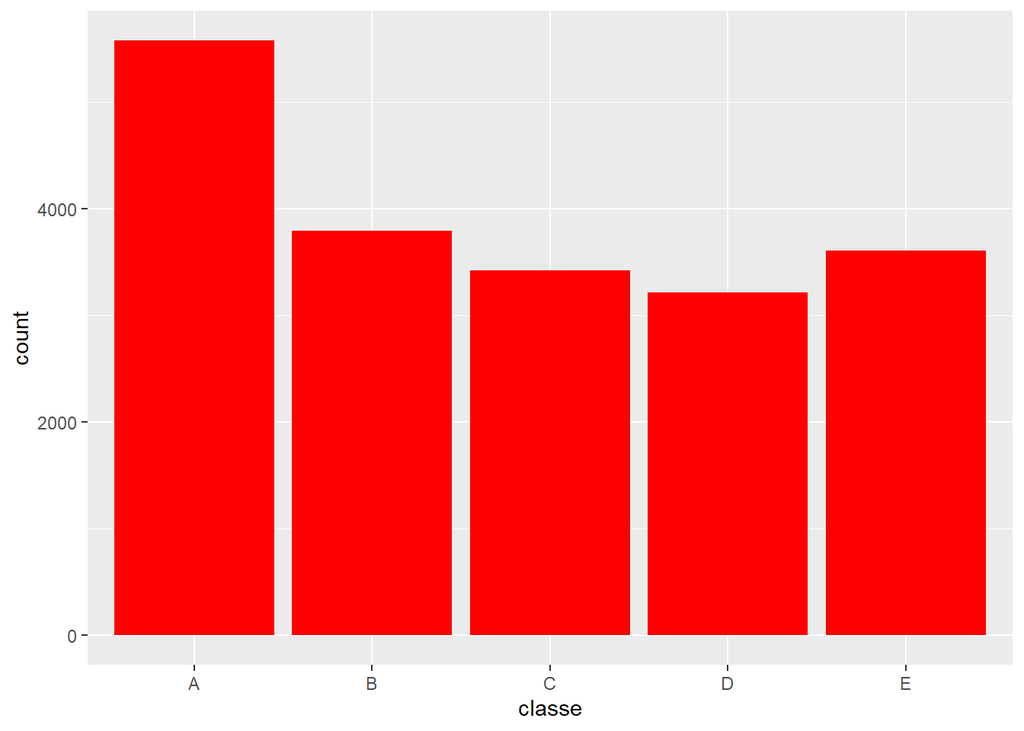

```r
ggplot(pml_training, aes(classe)) +  geom_bar(fill = "red")
```

The plot shows us that there are 5 possible responses A,B,C,D and E and they’re fairly well distributed.

# Data Cleaning

The first 7 columns of the dataset (X, user_name, raw_timestamp_part_1, raw_timestamp_part_2, cvtd_timestamp, new_window and num_window) are IDs and are therefore removed from a datset.

```r
# Remove columns that are IDs or stuff we do not need. In this case, the columns removed are X, user_name, raw_timestamp_part_1,
# raw_timestamp_part_2, cvtd_timestamp, new_window and num_window

pml_train<- pml_training[-c(1:7)]
pml_test <- pml_testing[-c(1:7)]
```

Now we’ll check if we have columns with NAs and remove them. Summing the number of NAs by column showed that the columns either had a very large number of NAs or none at all. So instead of removing rows with NAs or using dummy values (or means), I decided to drop those columns.(I also think the info from these columns is included in the columns without NAs)

```r
colSums(is.na(pml_training))

pml_train<-pml_train[,colSums(is.na(pml_train)) == 0]
pml_test <-pml_test[,colSums(is.na(pml_test)) == 0]

pml_train$classe <- factor(pml_train$classe)
```